# Numerical Data

Yuanting Lu

08/31/2022

### Load Data

We will continue work with the credit data, a simulated data set containing the credit information of a large number of customers[^1].

```r
credit <- read.csv('https://albums.yuanting.lu/sta126/22fa/credit.csv')
```

### Data set Overview

Some review questions from previous notes: What are the variables (columns) in this data set? Which of the variables are categorical? Which ones are **numerical**? Are the numerical variables **continuous** or **discrete**?

```r
head(credit)
```

[output not shown]

### Bar Graph

```r
table(credit$Cards)
```

[output not shown]

We can then visualize the frequency table in a bar graph. The ylim option sets the lower and upper limits of the y-axis (e.g., from 0 to 120).

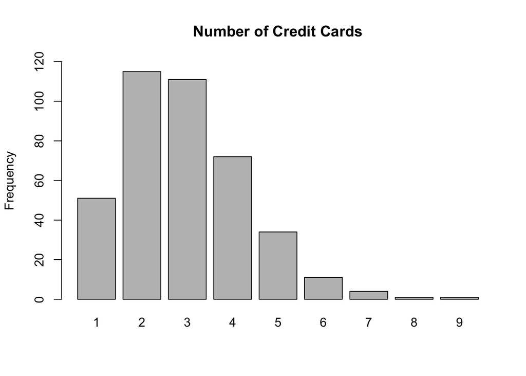

```r
barplot(table(credit$Cards), main = "Number of Credit Cards", ylim = c(0, 120), ylab = "Frequency")
```

### Lollipop Plot

The “line graph” in your book is more commonly known as the **lollipop plot**. The lollipop function is not a built-in R function. It is included in the nicer.R file written by your instructor.

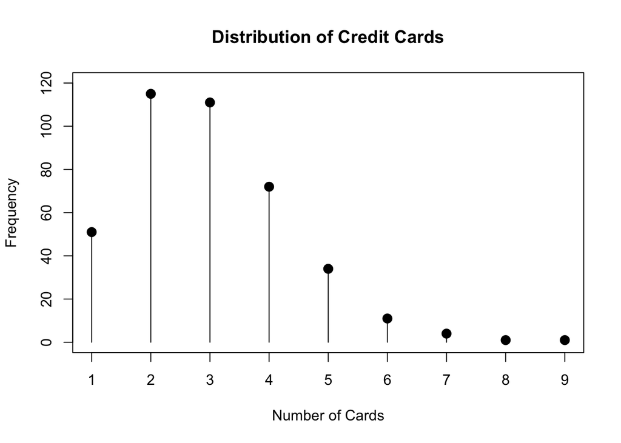

```r
source("https://albums.yuanting.lu/sta126/22fa/nicer.R")
ftable <- table(credit$Cards)
lollipop(ftable, ylim = c(0, 120), xlab = "Number of Cards",
         main = "Distribution of Credit Cards")
```

**Practice** Produce bar graphs or lollipop graphs for the variables `Age` and `Balance`. Do you see any issue on these graphs?

### Histogram

You probably notice that the bar graph looks ugly for both `Age` and `Balance`. In general, bar graphs work well with categorical or discrete variables that only have a small number of distinct values. When there are tons of distinct values or the variable is continuous, we break up the values into disjoint classes (bins) to display as a **histogram**. Unlike barplot that works with a frequency table, the hist function works with raw data. The xlab option adds a text label to the x-axis.

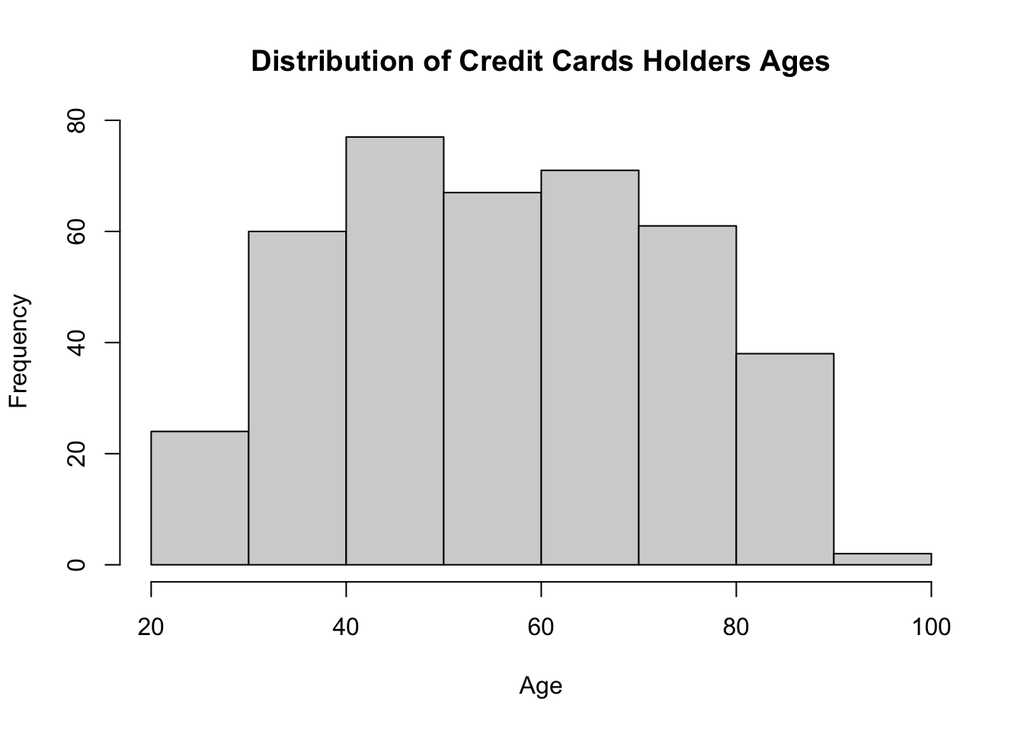

```r
hist(credit$Age, xlab = "Age", main = "Distribution of Credit Cards Holders Ages", right = FALSE)
```

- To manually set up the partition of the bins, add a `breaks` option. For example, `hist(credit$Age, breaks = c(0, 20, 40, 60, 80, 100), xlab = "Age")` will consolidate the `Age` data into 5 bins: [0, 20), [20, 40), [40, 60), [60, 80), and [80, 100).
- To make the bins left open and right closed, i.e., (0, 20], (20, 40], (40, 60], (60, 80], and (80, 100], use the option right = TRUE.

**Practice** Produce histograms for the other numerical variables. What are the **shapes of the distribution**?

### Frequency Polygon

A **frequency polygon** for a continuous variable is based on a histogram. Each bin of the histogram is represented a vertex, whose x-coordinate is the mid-point of the bin and y-coordinate is the frequency. Then, the polygon is completed by connecting all the representative points.

- The breaks option sets the partition points of the histogram bins.
- The pch option (**p**lot **ch**aracter) specifies the symbol for points. A value of 1 means empty circle. Adjust the value of the integer to see other type of symbols.

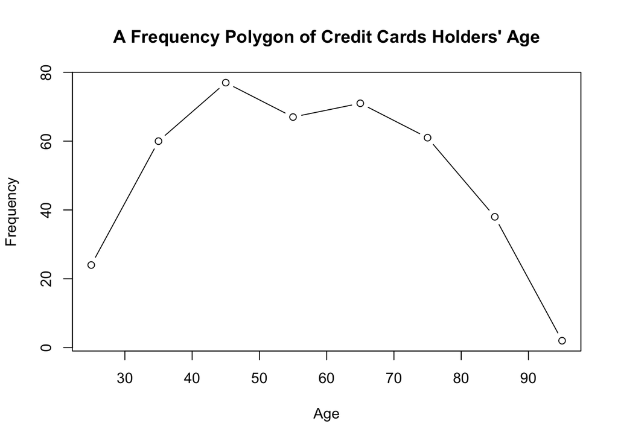

```r
source("https://albums.yuanting.lu/sta126/22fa/nicer.R")
freqpoly(credit$Age, breaks = c(20, 30, 40, 50, 60, 70, 80, 90, 100),
         pch = 1, xlab = 'Age', ylab = "Frequency",
         main = "A Frequency Polygon of Credit Cards Holders' Age")
```

**Practice** Produce frequency polygons for the variables `Balance` and `Cards`.

### Stem-and-Leaf Plot

In the histogram and the frequency polygon, we see the overall shape of the distribution but not the individual data. A Stem-and-leaf plot provides both and works well with small-to-moderate size data set. Below is a stem-and-leaf plot for the variable `Age`.[^2] Does it look like a rotated histogram?

```r
stem(credit$Age, scale = 0.5)
```

```
##
##   The decimal point is 1 digit(s) to the right of the |
##
##   2 | 344455555556778888899999
##   3 | 000000001112222222233333334444445555556666677777777888889999
##   4 | 00000001111111112222333334444444444444555556666666666777777777778888
##   5 | 0000000000001111112222223334444555556666666667777777777888888999999
##   6 | 00000012222223333344444444455555666666666666677777777778888889999999
##   7 | 0000000111111111222222233444455555555666667777788888889999999
##   8 | 00000001111111111222223333334444456779
##   9 | 18
```

### Descriptive Statistics

We will continue using the `Age` variable as examples for descriptive statistics.

| Statistics | Example | Notes |
| --- | --- | --- |
| Minimum | `min(credit$Age)` |  |
| Maximum | `max(credit$Age)` |  |
| Mean | `mean(credit$Age)` | Average. |
| Median | `median(credit$Age)` | Center. |
| Percentile | `quantile(credit$Age, 0.3, type = 2)`[^3] | The 30th percentile. |
| Five-number summary | `fivenum(credit$Age)` | Min, Q1, median, Q3, max. |
| Sample variance | `var(credit$Age)` |  |
| Sample standard deviation | `sd(credit$Age)` |  |

### Boxplot

Another popular type of graph to display continuous variable is the **boxplot**, also known as the **box and whisker plot**.

- The option horizontal = TRUE displays the boxplot horizontally. If we change it to FALSE, we will see vertical boxplot.
- In the option whisklty = 1 defines the **whisk**er **l**ine **ty**pe. The digit 1 means solid line[^4].

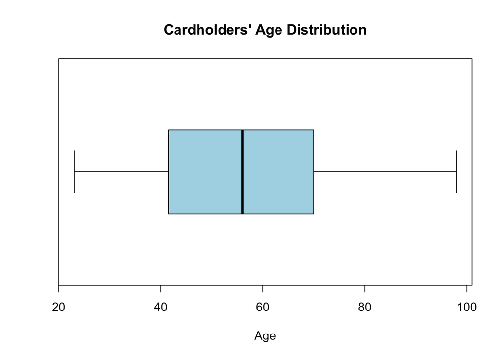

```r
boxplot(credit$Age, whisklty = 1, xlab = "Age", col = 'lightblue',
        horizontal = TRUE, main = "Cardholders' Age Distribution")
```

- The box marks the **interquartile range ($IQR$)** of the data set, i.e., $IQR = Q3 - Q1$.
- Any data value below $Q1-1.5\times IQR$ or above $Q3 + 1.5 \times IQR$ are considered as **outliers**.
- By default, a boxplot identifies outliers as open circles on the graph. If we add the option outline = FALSE, then the outliers (if any) will not be singled out.

**Classroom Activity** Observe the distribution of body temperature, heart rates, and semester credit hours for the entire class. Which statistics are good to measure the spread of the data?

Click [here](https://shiny.yuanting.lu/StandardDev) to submit your anonymous data.

### Empirical Rule

A data set is said to be **normal** if the histogram is bell-shaped and symmetric, with its highest at the middle interval.

If a data set is approximately normal with sample mean **$\bar{x}$** and sample standard deviation **$s$**, then the following are true.

- Approximately 68% of the observations lie between $\bar{x} - s$ and $\bar{x} + s$.
- Approximately 95% of the observations lie between $\bar{x} - 2s$ and $\bar{x} + 2s$.
- Approximately 99.7% of the observations lie between $\bar{x} - 3s$ and $\bar{x} + 3s$.

**Book Example 3.20** The stem-and-leaf plot displays 25 test scores.

```
##
##   The decimal point is 1 digit(s) to the right of the |
##
##   5 | 0358
##   6 | 22457
##   7 | 0035589
##   8 | 344669
##   9 | 004
```

**Book Example 3.21** The following data set has the weights of 200 people from a fitness club.

```r
club <- read.csv("https://albums.yuanting.lu/sta126/22fa/ex-3-21.csv")
```

1. Create a stem-and-leaf plot to show the distribution of weights for the 200 people. The distribution is **bimodal**.
2. Create stem-and-leaf plot for female and male club members separately. Run the following two lines to separate the club data set by gender.

```r
women <- club[which(club$Gender == "Female"), ]
men <- club[which(club$Gender == "Male"), ]
```

3. Verify the empirical rule in the female group.

### [Plus] Graphic Skills +

- Put multiple graphs in one canvas. The option mfrow = c(2, 2) in the par function divides the canvas into four subpanels, two rows and two columns.The subsequential graphs go into the subpanels row by row.[^5]
- Any thing after the *#* sign in a line is a comment. Comments are not run by *R*. They are there to make the codes more readable to the audience.
- The rug function and the jitter function combined add each individual data point as a tick mark just above the x-axis. It is a nice way to display the density of the distribution.
- The option xlab = NA in the histograms hides the x-axis labels.
- The option frame = FALSE in the boxplots hides the frame of the boxplots.

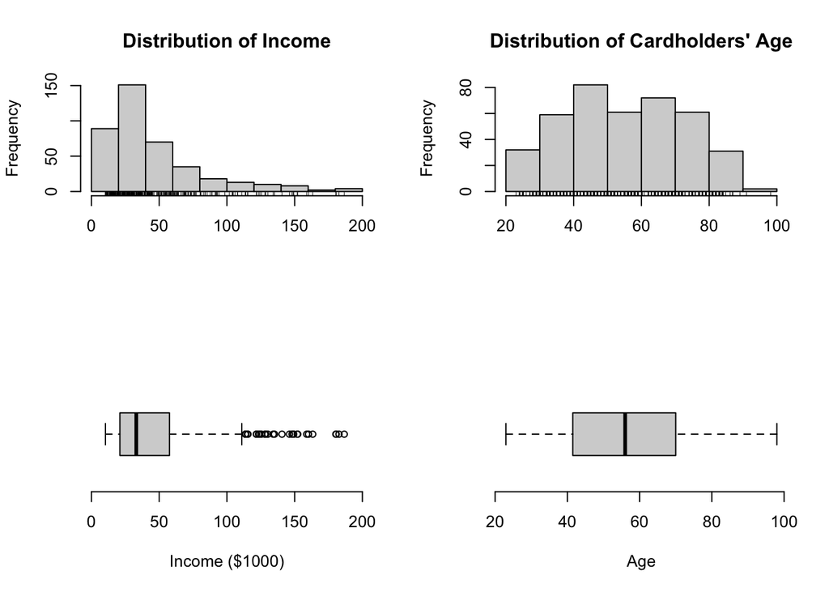

```r
par(mfrow = c(2, 2))

# Top left subpanel
hist(credit$Income, main = "Distribution of Income", xlab = NA)
rug(jitter(credit$Income))

# Top right subpanel
hist(credit$Age, main = "Distribution of Cardholders' Age", xlab = NA)
rug(jitter(credit$Age))

# Bottom left subpanel
boxplot(credit$Income, horizontal = TRUE, xlab = "Income ($1000)", frame = FALSE, ylim = c(0, 200))

# Bottom right subpanel
boxplot(credit$Age, horizontal = TRUE, xlab = "Age", frame = FALSE)
```

[^1]: Gareth James, Daniela Witten, Trevor Hastie, Robert Tibshirani. (2013). *An introduction to statistical learning : with applications in R*. New York: Springer.
[^2]: The default scale is 1. Adding an option scale = 2 will double the length of the graph, i.e., double the number of stems.
[^3]: There are 9 different ways in *R* to identify a percentile. The algorithm that agrees with our textbook definition is the second one, so we add the option type = 2.
[^4]: Change the digit from 1 to 6 to see other available line types.
[^5]: The mfrow in the par function creats equal space for each subpanel. To get more control of allocating spaces, look up the layout function.